# My_first_rmarkdown

## Arguments

echo

The argument echo specifies whether the R commands are included (default is TRUE). Adding echo=FALSE in the opening line of the R code block will not include the commmand: ```{r, echo=FALSE}

```
## [1] 1 2 3
```

```r
v = c(1,2,3)
v
```

```
## [1] 1 2 3
```

eval The argument eval specifies whether the R commands is evaluated (default is TRUE). Adding eval=FALSE in the opening line of the R code block will not evaluate the commmand: ```{r, eval=FALSE}. Now only the command is shown, but no output.

```r
v = c(1,2,3)
v
```

include

The argument include specifies whether the output is included (default is TRUE). Adding include=FALSE in the opening line of the R code block will not include the commmand: ```{r, include=FALSE}. Now the command and the output are both not shown, but the statement is evaluated.

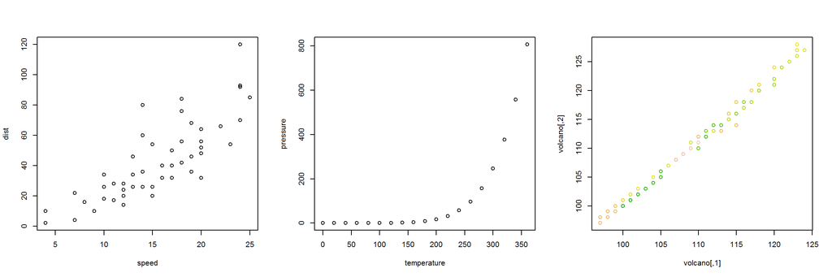

```r
par(mfrow=c(1,3))
plot(cars)
# simple comment
plot(pressure)
plot(volcano, col=terrain.colors(50))
```

## Running models on the server or analyses that take time

If you’re running analyses that take a long time, or you’re running the models on a server:

Include the script for the analysis in your R Markdown file, but make sure the model does not evaluate. Save the model, and load it for further use. For example, include something like this:

```r
library(CUB)
# Setting an if-statement to false, will prevent the evaluation of this part.
if(FALSE){
  # run this code on the server:
  model <- gam(Y ~ s(Time), data=dat)
  save(model, file="Models/model.rda", compress="xz")
}
# Now download the model, and store it in the directory Models
# Load the model:
load("Models/model.rda")
# ... and continue with your script.
```

Formatting the report The website http://rmarkdown.rstudio.com/authoring_pandoc_markdown.html provides more information on how to include lists, pictures, etc. Here only a few things are discussed.

# header 1: # header 1

## header 2: ## header 2

#### header 4: #### header 4

**bold text**: **bold** text *italics text*: *italics* text code text: `code` text inlcude a link: link